# Using dbinom and pbinom from R with Baseball Stats

Rick Dean

07/18/2020

The article by Joshua Cook titled Riddler: [Can You Beat MLB Recods?](https://joshuacook.netlify.app/post/riddler-beat-mlb-records/) inspired the content in this R markdown document.

```r
library(knitr)
library(ggplot2)
library(data.table)
library(RplotterPkg)
set.seed(123)
```

# 1 First question

If you have four at-bats per game, what are your chances of batting at least .400 over the course of the *60-game* season?

## 1.1 Solution

The solution is just the probability of observing a batting average of 0.400 or greater. The first value is computed using dbinom() and the second cumulative probability is calculated using pbinom(), setting lower.tail = FALSE to get the tail above 0.400.

1. Observing a batting average of 0.400:

```r
num_at_bats <- 60 * 4
real_batting_average <- 0.350
target_batting_average <- 0.400

prob_at_400 <- stats::dbinom(
  x = target_batting_average * num_at_bats,
  size = num_at_bats,
  prob = real_batting_average
  )
```

Note: `stats::dbinom()` gives the density.

The probability of observing a batting average of 0.400: 0.0144124

2. Observing a batting average greater than 0.400:

```r
prob_above_400 <- stats::pbinom(
  q = target_batting_average * num_at_bats,
  size = num_at_bats,
  prob = real_batting_average,
  lower.tail = FALSE
)
prob_at_above_400 <- prob_at_400 + prob_above_400
```

Note: `stats::pbinom()` gives the distribution function.

The probability of observing a batting average above 0.400: 0.0464262

Total probability of observing a batting average at or above 0.400: 0.0608386

There is a 6.1% chance of reaching a batting average of 0.400 in the shorter season

# 2 Second question

If you have four at-bats per game, what are your chances of batting at least .400 over the course of the *162-game* season?

## 2.1 Solution

Only the probability of a batting average greater than 0.400 needs to be calculated (because .400 * 162 * 4 is a non-integer value).

```r
num_at_bats <- 162 * 4
real_batting_average <- 0.350
target_batting_average <- 0.400

prob_above_400_162_games <- stats::pbinom(
  q = target_batting_average * num_at_bats,
  size = num_at_bats,
  prob = real_batting_average,
  lower.tail = FALSE
)
```

With 162 games, there is a probability 0.0037899 of achieving a batting average of at least 0.400.

# 3 Simulation solution

The solution to this riddle could also be found by simulating a whole bunch of seasons with the real batting average of 0.350 and then just counting how frequently the simulations resulted in an observed batting average of 0.400.

## 3.1 Solution for 1 simulation (season)

The returned value is a sampled number of hits (“successes”) over the season from the binomial distribution. For n = 1, a single season:

```r
num_at_bats <- 60 * 4
real_batting_average <- 0.350

hits_1 <- stats::rbinom(
  n = 1,
  size = num_at_bats,
  prob = real_batting_average
)
batting_average_1 <- hits_1/num_at_bats
```

The simulated hits for 1 season: 81

The simulated average batting for 1 season: 0.3375

## 3.2 Solution for 10000 simulations (seasons)

Taking n = 10000 simulations

```r
num_at_bats <- 60 * 4
real_batting_average <- 0.350

hits_10000 <- stats::rbinom(
  n = 10000, # 10000 simulations
  size = num_at_bats,
  prob = real_batting_average
)
batting_averages <- hits_10000/num_at_bats
batting_average_10000 <- mean(batting_averages)
```

The simulated average batting across 10000 seasons: 0.3508 which is close to *real_batting_average*.

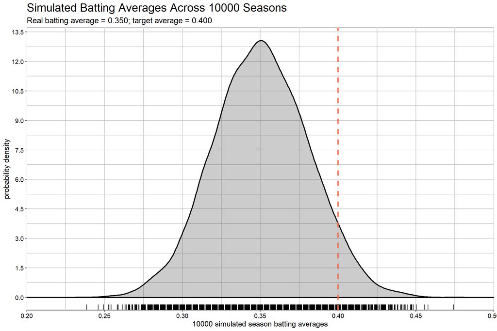

```r
target_batting_average <- 0.400
batting_averages_dt <- data.table(
  x = batting_averages
)
RplotterPkg::create_density_plot(
  df = batting_averages_dt,
  aes_x = "x",
  title = "Simulated Batting Averages Across 10000 Seasons",
  subtitle = "Real batting average = 0.350; target average = 0.400",
  x_title = "10000 simulated season batting averages",
  y_title = "probability density",
  density_fill = "black",
  density_alpha = 0.2,
  x_limits = c(0.2,0.5),
  x_major_breaks = seq(0.2, 0.5, 0.05),
  y_major_breaks = seq(0.0, 13.5, 1.5),
  rot_y_tic_label = TRUE,
  plot_obs = TRUE,
  plot_obs_jitter = TRUE
) +
  geom_vline(xintercept = target_batting_average, color="tomato", lty = 2, size = 1.2)
```

### 3.2.2 Probability of a batting average greater than 0.400 from the simulation

```r
prob_at_above_400_simulation <- mean(batting_averages >= 0.40)
```

From the simulation the average batting probabilities at or greater than .400 is 0.064 which is close to the above actual answer of 0.0608386.

# 4 Why the length of the season matters to the distribution

The function `stats::rbinom()` generates a vector of binomial distributed random variables given a vector length *n*, number of trials *size*, and probability of success on each trial *prob*.

## 4.1 Generate a single season of “at-bats” using `stats::rbinom()`

4 “at-bats” per game over 60 game season with a batting average of 0.350

```r
sampled_season_hits <- stats::rbinom(n = 60*4, size = 1, prob = 0.350)
season_hits_dt <- data.table(
  hits = sampled_season_hits,
  at_bat = 1:length(sampled_season_hits),
  cum_hits = cumsum(sampled_season_hits),
  batting_avg = cumsum(sampled_season_hits)/1:length(sampled_season_hits)
)
```

## 4.2 Plot the running batting average over a single simulated season

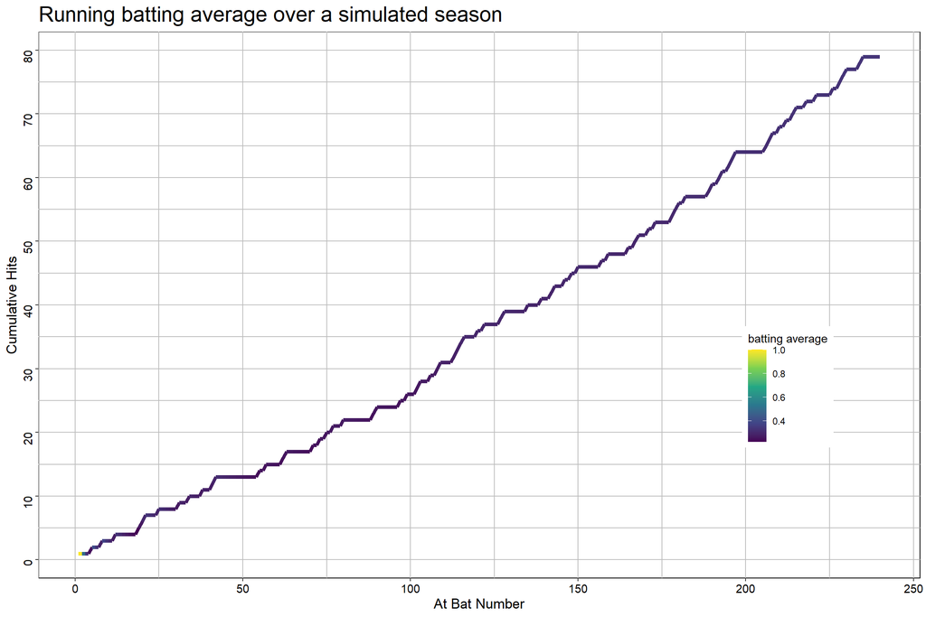

```r
RplotterPkg::create_scatter_plot(
  df = season_hits_dt,
  aes_x = "at_bat",
  aes_y = "cum_hits",
  aes_color = "batting_avg",
  title = "Running batting average over a simulated season",
  x_title = "At Bat Number",
  y_title = "Cumulative Hits",
  y_major_breaks = seq(0, 90, 10),
  connect = TRUE,
  show_pts = FALSE,
  line_size = 1.6
) + ggplot2::scale_color_viridis_c() +
  theme(legend.position = c(0.85, 0.35)) +
  labs(color = "batting average")
```

## 4.3 Plot the running batting average over multiple simulated seasons